# DATA100 Introduction to Data Analytics

Lecture 10: Fancy Words and Numbers

Agassi Iu

Wilfrid Laurier University

2026-10-27

# The story

## A night in the life of a student

Last lecture, about 4 in 10 `bedtime` answers were still unreadable. Today we will finish the job, then ask what the *clean* times tell us:

1. When do students go to bed? (*Regular expressions*, Chapter 15)
2. When do they wake up, and who is still awake at 1 AM? (*Dates and times*, Chapter 17)

## Setup and data

The data is the same sleep survey from Lectures 8 and 9.

```r
library(dplyr); library(tidyr); library(tibble); library(readr)
library(ggplot2); library(stringr); library(forcats); library(lubridate)

survey <- read_csv("data/sleep_survey_v2.csv", show_col_types = FALSE)
```

**Not everything fits in this 80-minute lecture**

I may leave some of the undiscussed functions or tools in an *appendix table* at the end of the slide deck. Each row will say what the tool does and which section of the chapter to read. You should definitely take a look at the text for more details.

# Part 1: Regular expressions

## When do students go to bed?

Our goal: turn every typed `bedtime` into an hour and a minute on a 24-hour clock.

| Step | Tool (Chapter 15) |
| --- | --- |
| Test for a pattern | `str_detect()`, `regex(ignore_case = TRUE)` |
| Describe a pattern | `\\d`, `[:.]`, `?`, `{1,2}`, `^`, `$`, `(am\\|pm)` |
| Tidy the text | `str_replace()`, `str_remove()` |
| Pull the pieces out | `separate_wider_regex()` |
| Decide the rules | `case_when()` (Lecture 8) |

## Does it match?

**`str_detect(x, pattern)`**

This function returns a logical vector. It takes a look at `x` and asks for the `pattern`. It returns a `TRUE` where the pattern is found.

## Building blocks of a pattern

| Pattern | Matches |
| --- | --- |
| `.` | any **one** character |
| `\\.` | a real dot |
| `\\d` | one digit |
| `[:.]` | a colon **or** a dot |
| `?` | the piece before it is optional (0 or 1 times) |
| `{1,2}` | the piece before it appears 1 or 2 times |
| `^` and `$` | the start and the end of the string |
| `(am\|pm)` | `am` **or** `pm` |

**Two backslashes in R**

In an R string, a backslash must be **escaped**. To get the regex `\d`, you type `"\\d"`. To match a real dot, you type `"\\."`, because a plain `.` matches anything.

## A pattern for the standard format

`"11:30 pm"` is: one or two digits, a colon, two digits, an optional space, then `am` or `pm`.

- `^` and `$` force the pattern to match the **whole** string
- Without them, `"around 11:30 pm"` would also match

## How many bedtimes match?

## What is left?

The trick with regular expressions: look at what does **not** match, and improve the pattern.

## Cleaning

- `str_replace(x, pattern, replacement)` replaces the **first** match
- `str_remove(x, pattern)` deletes it
- `str_replace_all()` replaces **every** match (see the appendix)

## Pulling the pieces out

**`separate_wider_regex()`**

Last lecture we split on a space. A regular expression can split on a *pattern*. Each named piece becomes a column; unnamed pieces are matched and dropped.

**Optional pieces**

`\\d{0,2}` allows **no** minutes, and the empty option at the end of `am|pm|` allows **no** `am` or `pm`. Strings that do not fit at all, like `idk`, become `NA`.

## Deciding the rules

**We need rules!**

Some answers have no `am` or `pm`: `23:30`, `0100`, or just `11:30`. If it is

- Already 24-hour (13 to 23, or 0): keep the hour
- 6 to 11 with no `am` or `pm`: assume **evening** (add 12)
- 12 or 1 to 5 with no `am` or `pm`: assume **after midnight**

**Order matters**

`case_when()` uses the first match, as we talked about this with *Logical Vectors*. The 24-hour rule comes before the “6 to 11” rule for a reason.

## Putting Part 1 together

## The answer so far

**What is still missing?**

Blank answers and answers like `idk` are still `NA`. We cannot recover what students did not tell us.

## Aside: What happens to the rest of the unused responses?

```r
survey_clean |>
  filter(is.na(hour24)) |>
  count(bedtime, sort = TRUE)
```

```
# A tibble: 7 × 2
  bedtime         n
  <chr>       <int>
1 <NA>           23
2 it changes      8
3 no set time     7
4 varies          6
5 n/a             5
6 depends         4
7 idk             4
```

## Exercise 1

**Live exercise**

1. Count the bedtimes written as **four digits** with an optional colon, like `23:30` or `2330`.
2. Find every bedtime that contains the word `midnight` in **any capitalisation**, and count each spelling.

# Part 2: Dates and times

## When do they wake up?

Wake-up time is **bedtime plus sleep**. To add them we need real date-times, just not text!

| Step | Tool (Chapter 17) |
| --- | --- |
| Create date-times | `ymd()`, `ymd_hms()`, `make_datetime()` |
| Get the pieces | `hour()`, `minute()`, `wday()` |
| Add time | `hours()`, `dhours()` |
| Test for overlap | `interval()`, `%within%` |
| Fix the time zone | `force_tz()`, `with_tz()` |

## Creating date-times from text

**Any separator works**

`ymd()` ignores dashes, slashes, and spaces. Only the order of year, month and day matters.

## Creating date-times from parts

**`make_datetime()`**

This function builds a date-time from separate numbers. Adding *periods* such as `hours()` moves the clock forward.

- This is how we handle bedtimes *after midnight*: add 24 hours, and the date rolls over

## Bedtime as a date-time

- Use `if_else()` to add 24 to the after-midnight hours
- `tz = "America/Toronto"` is the time zone. More on that soon

## Getting the pieces back

**Checkpoint**

What is the difference between `wday(t)` and `day(t)`?

## Time spans

**Two way to add time**

- **Durations** (`dhours()`, `ddays()`) are an exact number of seconds
- **Periods** (`hours()`, `days()`) move the **clock** by a calendar amount

**When to use it?**

- Use *durations* for how long something lasts, like sleep.
- Use *periods* for calendar time.

## Daylight Savings

**Which one should I use?**

`days(1)` gives midnight on November 2 where the clock moved one day. `ddays(1)` gives *11 PM*: exactly 24 hours later, but the clocks jumped back in 1 hour.

## Duration

**Quick Maths**

`Wake-up time = bedtime + sleep`. Sleep is a duration, so we use `dhours()`.

## Do students with an early class wake up earlier?

## Average wake-up time

## Who is asleep at 1 AM?

**Interval**

The stretch of time between two date-times. `x %within% interval` is `TRUE` when `x` falls inside the interval.

## Who is asleep at 1 AM?

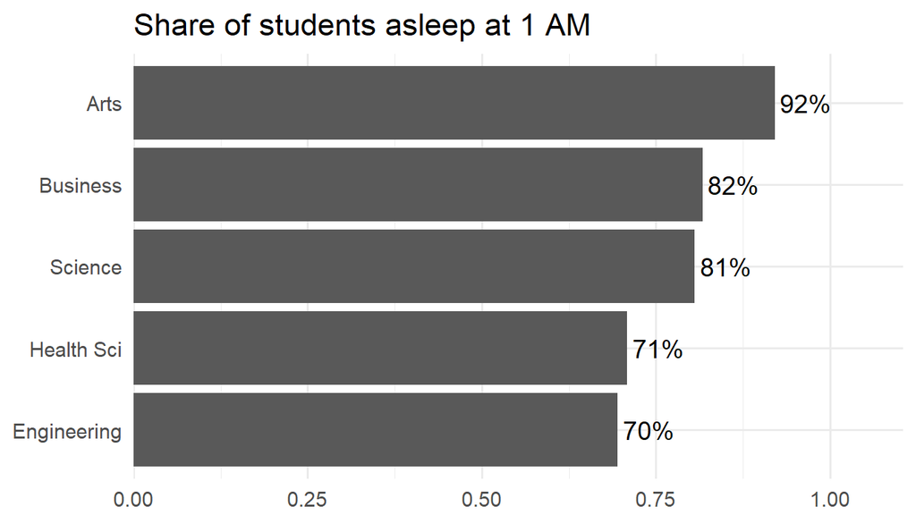

## Code

```r
asleep |>
  group_by(program) |>
  summarize(share_asleep = mean(asleep_1am)) |>
  mutate(program = fct_reorder(program, share_asleep)) |>
  ggplot(aes(x = share_asleep, y = program)) +
  geom_col() +
  geom_text(aes(label = scales::percent(share_asleep, accuracy = 1)), hjust = -0.1) +
  scale_x_continuous(expand = expansion(mult = c(0, 0.2))) +
  labs(
    title = "Share of students asleep at 1 AM",
    x = NULL, y = NULL
  ) +
  theme_minimal(base_size = 14)
```

## Better sleep = better grades?

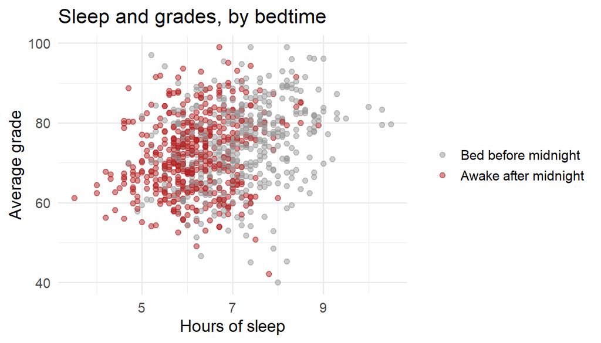

## Code

```r
sleep_times |>
  mutate(
    after_midnight = bedtime_dt > make_datetime(2026, 10, 28, tz = "America/Toronto")
  ) |>
  filter(!is.na(avg_grade)) |>
  ggplot(aes(x = sleep_hours, y = avg_grade, colour = after_midnight)) +
  geom_point(alpha = 0.5) +
  scale_colour_manual(
    values = c("FALSE" = "grey60", "TRUE" = "firebrick"),
    labels = c("Bed before midnight", "Awake after midnight"),
    name = NULL
  ) +
  labs(
    title = "Sleep and grades, by bedtime",
    x = "Hours of sleep", y = "Average grade"
  ) +
  theme_minimal(base_size = 14)
```

## What does the scatter plot say?

**What is after midnight?**

We used `>`, so a student at exactly 12:00 AM counts as **before** midnight. Change it to `>=` and see what happens. Boundaries matter, as with `cut()` last lecture.

**Observations**

The red points sit to the left: students who go to bed after midnight sleep less. They also have slightly lower grades, but the two clouds overlap a lot.

## Exercise 2

**Live exercise**

Suppose that I have given you a tiny data set of three students. Their bedtime is a date-time, and sleep is in hours.

1. Compute each student’s wake-up time.
2. Is each student asleep at 3:00 AM on October 28?
3. What share of the three students is asleep at 3:00 AM?

# Wrap-up

## Summary

| Question | Chapter | Tools we used |
| --- | --- | --- |
| When do they go to bed? | *Regular expressions* | `str_detect()`, `str_replace()`, `str_remove()`, `separate_wider_regex()` |
| When do they wake up, and who is awake at 1 AM? | *Dates and times* | `make_datetime()`, `hours()`, `dhours()`, `interval()`, `%within%` |

## What’s next, and sources

**Lecture 11: Missing values and joins**

- **Missing values**: filling gaps, like the hours with no responses
- **Joins**: bringing the drinks table into the survey

**Attribution**

Content adapted from *R for Data Science (2e)* by Hadley Wickham, Mine Çetinkaya-Rundel, and Garrett Grolemund:

- Chapter 15: Regular expressions, https://r4ds.hadley.nz/regexps.html
- Chapter 17: Dates and times, https://r4ds.hadley.nz/datetimes.html

# Appendix: read the text

## Regular expressions: other tools (i)

| Tool | What it does | Tiny example | Read the section on |
| --- | --- | --- | --- |
| `str_count()` | Counts how many times a pattern appears in each string | `str_count("banana", "a")` | Counting matches |
| `str_extract()` | Pulls out the matching text itself | `str_extract("11:30 pm", "\\d+")` | Extracting |
| `str_replace_all()` | Replaces **every** match, not just the first | `str_replace_all("a.b.c", "\\.", "-")` | Replacing values |

## Regular expressions: other tools (ii)

| Tool | What it does | Tiny example | Read the section on |
| --- | --- | --- | --- |
| `str_view()` | Shows where a pattern matches, highlighted | `str_view(x, "pm")` | Pattern basics |
| Back references: `\\1` | Reuses the text a group captured | `str_replace(x, "(\\d+)h", "\\1 hours")` | Grouping and capturing |
| `fixed()` | Matches the exact text, with no special characters | `str_detect(x, fixed("."))` | Fixed matches |

## Regular expressions: other tools (iii)

| Tool | What it does | Tiny example | Read the section on |
| --- | --- | --- | --- |
| `regex()` flags | `multiline`, `comments`, and more | `regex("pm", ignore_case = TRUE)` | Pattern control |
| `+`, `*` | One or more, zero or more | `"\\d+"` | Quantifiers |
| `[^...]` | Anything **except** these characters | `"[^0-9]"` | Character classes |

## Regular expressions: other tools (iv)

| Tool | What it does | Tiny example | Read the section on |
| --- | --- | --- | --- |
| `\\s`, `\\w` | A space; a letter, digit or underscore | `"\\s+"` | Character classes |
| Parentheses | Control the order of `\\|` and quantifiers | `"(am&#124;pm)$"` | Operator precedence |

## Dates and times: other tools (i)

| Tool | What it does | Tiny example | Read the section on |
| --- | --- | --- | --- |
| `make_date()` | Builds a date from year, month and day | `make_date(2026, 10, 6)` | Creating date-times |
| `as_datetime()`, `as_date()` | Converts between a date and a date-time | `as_date(now())` | Creating date-times |
| `yday()`, `mday()` | Day of the year, day of the month | `yday(ymd("2026-10-06"))` | Getting components |
| `round_date()`, `ceiling_date()` | Round to the nearest unit, or up | `ceiling_date(x, "hour")` | Rounding |

## Dates and times: other tools (ii)

| Tool | What it does | Tiny example | Read the section on |
| --- | --- | --- | --- |
| `update()` | Changes one component of a date-time | `update(x, hour = 6)` | Modifying components |
| `as.duration()` | Turns a time difference into a duration | `as.duration(end - start)` | Durations |
| `%--%` | A shortcut for `interval()` | `start %--% end` | Intervals |

## Dates and times: other tools (iii)

| Tool | What it does | Tiny example | Read the section on |
| --- | --- | --- | --- |
| `int_length()` | The length of an interval in seconds | `int_length(sleeping)` | Intervals |
| `Sys.timezone()` | Your computer’s time zone | `Sys.timezone()` | Time zones |

**Everything has a time zone**

Date-times without an explicit time zone are treated as **UTC**. Always check with `tz()` before you compute hours.